# Regularización: Lasso, Ridge y Elastic Net

Juan Manuel Barriola y Diego Kozlowski

10-11-2018

```r
library(dplyr)
library(tidyr)
library(broom)
library(ggplot2)
library(ISLR)
library(GGally)
library(modelr)
library(cowplot)
library(glmnet)
library(rlang)
library(purrr)
library(caret)
set.seed(1992)
```

Las técnicas de regularización son útiles para trabajar con conjuntos con gran cantidad de variables, las cuales pueden introducir variabilidad en las estimaciones de los parámetros. El problema que vamos a tratar de resolver es predecir el salario de un jugador de la NBA en base a ciertos predictores.

## Conjunto de datos

Vamos a utilizar dos conjuntos de datos provenientes de Kaggle:

1. **stats** cuenta con las estadísticas de los jugadores (https://www.kaggle.com/koki25ando/salary)
2. **salary** cuenta con los salarios de los jugadores (https://www.kaggle.com/drgilermo/nba-players-stats)

Year: Season

Player: name

Pos: Position

Age: Age

Tm: Team

G: Games

GS: Games Started

MP: Minutes Played

PER: Player Efficiency Rating

TS%: True Shooting % : medida de eficiencia del jugador al lanzar

3PAr: 3-Point Attempt Rate

FTr:Free Throw Rate

ORB%: Offensive Rebound Percentage

DRB%: Defensive Rebound Percentage

TRB%: Total Rebound Percentage

AST%: Assist Percentage

STL%: Steal Percentage

BLK%: Block Percentage

TOV%: Turnover Percentage

USG%: Usage Percentage

OWS: Offensive Win Shares

DWS: Defensive Win Shares

WS: Win Shares

WS/48: Win Shares Per 48 Minutes

OBPM: Offensive Box Plus/Minus

DBPM: Defensive Box Plus/Minus

BPM: Box Plus/Minus : comparaciones contra el “jugador promedio” de la NBA

VORP: Value Over Replacement: Medida vinculada al BPM

FG: Field Goals

FGA: Field Goal Attempts

FG%: Field Goal Percentage

3P: 3-Point Field Goals

3PA: 3-Point Field Goal Attempts

3P%: 3-Point Field Goal Percentage

2P: 2-Point Field Goals

2PA: 2-Point Field Goal Attempts

2P%: 2-Point Field Goal Percentage

eFG%: Effective Field Goal Percentage

FT: Free Throws

FTA: Free Throw Attempts

FT%: Free Throw Percentage

ORB: Offensive Rebounds

DRB: Defensive Rebounds

TRB: Total Rebounds

AST: Assists

STL: Steals

BLK: Blocks

TOV: Turnovers

PF: Personal Fouls

PTS:Points

```r
# Los datos de salario son para la temporada 2017-2018
salarios <- read.csv("NBA_season1718_salary.csv", stringsAsFactors = F) %>% rename(salary=season17_18)
# Filtramos las estadisticas para quedarnos con la temporada 2017
estadisticas <- read.csv("Seasons_Stats.csv", stringsAsFactors = F) %>% filter(Year>= 2017) %>% select(-c(blanl, blank2))
glimpse(salarios)
```

```
Observations: 573
Variables: 4
$ X      <int> 1, 2, 3, 4, 5, 6, 7, 8, 9, 10, 11, 12, 13, 14, 15, 16, 17, 18, 19, 20, 21, 22, 23, 24, 25, 26, 27, 28, 29, 30, 31, 32, 33, 34, 3...
$ Player <chr> "Stephen Curry", "LeBron James", "Paul Millsap", "Gordon Hayward", "Blake Griffin", "Kyle Lowry", "Russell Westbrook", "Mike Con...
$ Tm     <chr> "GSW", "CLE", "DEN", "BOS", "DET", "TOR", "OKC", "MEM", "HOU", "TOR", "BOS", "OKC", "POR", "NOP", "MIA", "GSW", "WAS", "HOU", "P...
$ salary <dbl> 34682550, 33285709, 31269231, 29727900, 29512900, 28703704, 28530608, 28530608, 28299399, 27739975, 27734405, 26243760, 26153057...
```

```r
colnames(estadisticas)
```

```
 [1] "X"      "Year"   "Player" "Pos"    "Age"    "Tm"     "G"      "GS"     "MP"     "PER"    "TS."    "X3PAr"  "FTr"    "ORB."   "DRB."   "TRB."
[17] "AST."   "STL."   "BLK."   "TOV."   "USG."   "OWS"    "DWS"    "WS"     "WS.48"  "OBPM"   "DBPM"   "BPM"    "VORP"   "FG"     "FGA"    "FG."
[33] "X3P"    "X3PA"   "X3P."   "X2P"    "X2PA"   "X2P."   "eFG."   "FT"     "FTA"    "FT."    "ORB"    "DRB"    "TRB"    "AST"    "STL"    "BLK"
[49] "TOV"    "PF"     "PTS"
```

Vemos que salarios contiene el nombre, equipo y salario en dolares de los jugadores.

Estadisticas es una tabla que contiene 51 variables, de las cuales 46 contienen informacion distintas estadisticas de la temporada 2017-2018.

Hacemos el join por jugador y equipo. Un jugador puede ser cambiado/vendido durante la temporada. Asi mantenemos a los jugadores con las estadisticas correspondientes al equipo con quien acordaron el salario.

```r
nba <- inner_join(salarios, estadisticas, by=c('Player', 'Tm')) %>%
  select(-c(X.x, X.y, Year)) %>%
  drop_na() # Eliminamos los NA
```

## Analisis Exploratorio

#### Gráfico de la relacion entre la posicion y el salario

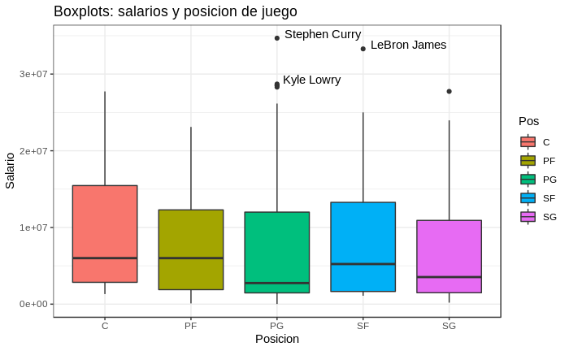

```r
ggplot(nba, aes(Pos, salary, fill=Pos)) +
  geom_boxplot() +
  geom_text(aes(label=ifelse(salary>28700000,as.character(Player),'')),hjust=-0.1,vjust=0) +
  theme_bw() +
  labs(title= "Boxplots: salarios y posicion de juego", x="Posicion", y="Salario")
```

#### Correlagrama

```
data in column(s) 'Player', 'Tm', 'Pos' are not numeric and were ignored
```

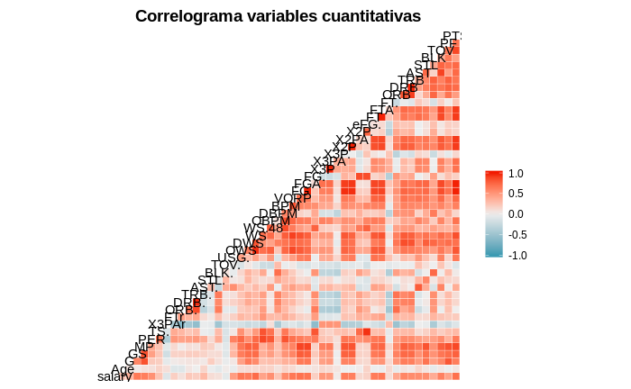

```r
ggcorr(nba, layout.exp = 2) + labs(title='Correlograma variables cuantitativas')
```

#### GGpairs (algunas variables)

Seleccionamos algunas variables y vemos sus relaciones usando `ggpairs`.

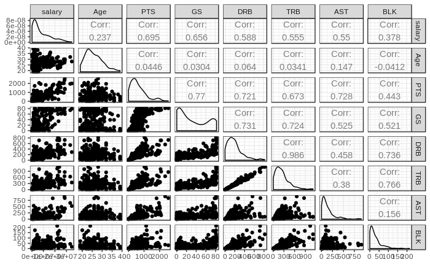

```r
nba %>% select(salary, Age, PTS, GS, DRB, TRB, AST, BLK) %>% ggpairs() + theme_bw()
```

## Modelo Lineal

Vamos a probar un modelo lineal que incluya todas las variables (excepto al jugador y equipo). Obtengan las estimaciones de los parametros junto a su p-valor e intervalo de confianza.

### Coeficientes estimados

Vemos los coeficientes estimados y sus p-valores asociados

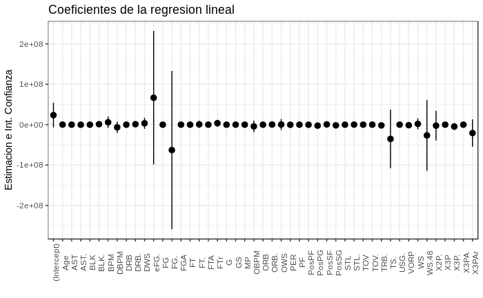

```r
# Eliminamos jugador y equipo
nba = nba %>% select(-c(Player, Tm))
# Modelo lineal
modelo_lineal = nba %>% lm(formula = salary~., data = .)
#Coeficientes
lineal_coef= modelo_lineal %>% tidy(conf.int=TRUE)
ggplot(lineal_coef, aes(term, estimate))+
  geom_point()+
  geom_pointrange(aes(ymin = conf.low, ymax = conf.high))+
  labs(title = "Coeficientes de la regresion lineal", x="", y="Estimacion e Int. Confianza") +
  theme_bw() +
  theme(axis.text.x = element_text(angle=90))
```

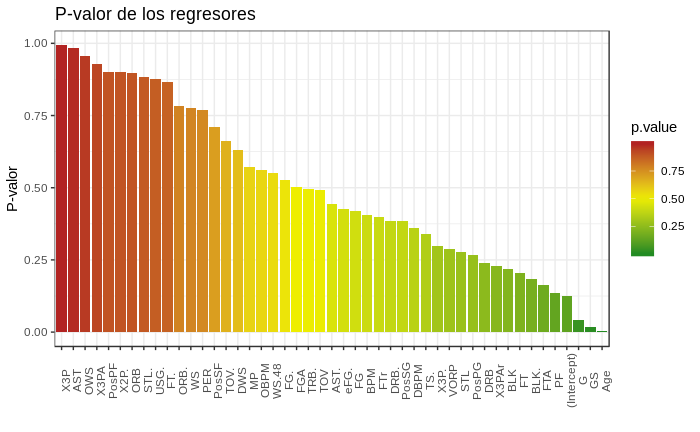

```r
ggplot(lineal_coef, aes(reorder(term, -p.value), p.value, fill=p.value))+
  geom_bar(stat = 'identity', aes(fill=p.value))+
  labs(title = "P-valor de los regresores", x="", y="P-valor") +
  theme_bw() +
  theme(axis.text.x = element_text(angle=90)) +
  scale_fill_gradient2(high='firebrick', low = 'forestgreen', mid='yellow2',midpoint = 0.5 )
```

¿Qué notamos aqui?

Hay ciertas coeficientes estimados que presentan una gran variabilidad pero la escala de las variables puede ocultarnos la verdadera variabilidad de los estimadores.

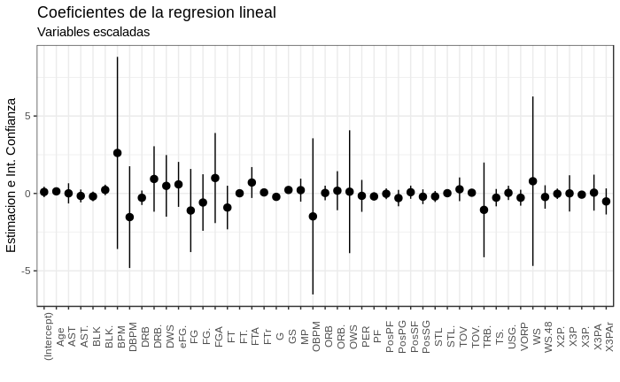

```r
# Reescalamos las variables numericas
nba_scaled = nba %>% mutate_at(vars(-Pos), scale)
# Nuevo modelo lineal
modelo_lineal_scal = nba_scaled %>% lm(formula = salary~., data = .)
lineal_coef_scal = modelo_lineal_scal %>% tidy(conf.int=TRUE)
ggplot(lineal_coef_scal, aes(term, estimate))+
  geom_point()+
  geom_pointrange(aes(ymin = conf.low, ymax = conf.high))+
  labs(title = "Coeficientes de la regresion lineal", subtitle="Variables escaladas", x="", y="Estimacion e Int. Confianza") +
  theme_bw() +
  theme(axis.text.x = element_text(angle=90))
```

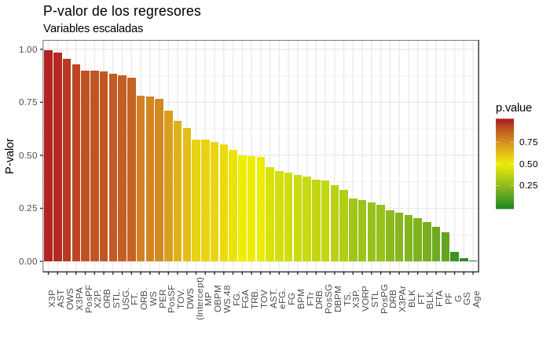

```r
ggplot(lineal_coef_scal, aes(reorder(term, -p.value), p.value, fill=p.value))+
  geom_bar(stat = 'identity', aes(fill=p.value))+
  labs(title = "P-valor de los regresores",subtitle="Variables escaladas", x="", y="P-valor") +
  theme_bw() +
  theme(axis.text.x = element_text(angle=90)) +
  scale_fill_gradient2(high='firebrick', low = 'forestgreen', mid='yellow2',midpoint = 0.5 )
```

### Evaluacion de los modelos

Obtemos la evaluacion de ambos modelos ¿Cómo esperan que sean los valores de diagnóstico para ambos modelos?

```r
modelo_lineal = modelo_lineal %>% glance() %>% select(r.squared, adj.r.squared, p.value)
modelo_lineal_scal = modelo_lineal_scal %>% glance() %>% select(r.squared, adj.r.squared, p.value)
bind_rows(modelo_lineal, modelo_lineal_scal) %>% mutate(modelo= c('lineal', 'lineal_escalado'))
```

| r.squared | adj.r.squared | p.value | modelo |
| --- | --- | --- | --- |
| 0.693241 | 0.6240698 | 2.186855e-32 | lineal |
| 0.693241 | 0.6240698 | 2.186855e-32 | lineal_escalado |

## Partición Train y Testing

Realizamos una partición entre dataset de entrenamiento y testeo usando la función `resample_partition` del paquete **modelr**

```r
train_test <- nba %>% resample_partition(c(train=0.7,test=0.3))
nba <- train_test$train %>% as_tibble()
test <- train_test$test %>% as_tibble()
```

## Regularizacion

La libreria **glmnet** es permite trabajar con modelos ridge, lasso y elastic net. La funcion que vamos a utilizar es `glmnet`. Es necesario que le pasemos un objeto *matriz* con los regresores y un vector con la variable a explicar (en este caso los salarios)

Con el parametro $\alpha$ indicamos con que tipo de modelo deseamos trabajar:

- Ridge: $\alpha=0$
- Lasso: $\alpha=1$
- Elastic Net: $0<\alpha<1$

### Lasso

En este caso vamos a trabajar con $\alpha=1$.

1. ¿Cuál es la penalización que introduce el modelo Lasso?
2. ¿Cómo impacta esto en las variables?

```r
# Vector con los salarios
nba_salary = nba$salary
# Matriz con los regresores
nba_mtx = model.matrix(salary~., data = nba)
# Modelo Lasso
lasso.mod=glmnet(x=nba_mtx, # Matriz de regresores
                 y=nba_salary, #Vector de la variable a predecir
                 alpha=1, # Indicador del tipo de regularizacion
                 standardize = F) # Que esta haciendo este parametro?

lasso_coef = lasso.mod %>% tidy()
lasso_coef
```

| term | step | estimate | lambda | dev.ratio |
| --- | --- | --- | --- | --- |
| (Intercept) | 1 | 8.195289e+06 | 4167816624.8 | 0.00000000 |
| (Intercept) | 2 | 7.387106e+06 | 3797559283.1 | 0.06956099 |
| MP | 2 | 5.509129e+02 | 3797559283.1 | 0.06956099 |
| (Intercept) | 3 | 6.650719e+06 | 3460194583.2 | 0.12731175 |
| MP | 3 | 1.052884e+03 | 3460194583.2 | 0.12731175 |
| (Intercept) | 4 | 5.979752e+06 | 3152800433.4 | 0.17525744 |
| MP | 4 | 1.510262e+03 | 3152800433.4 | 0.17525744 |
| (Intercept) | 5 | 5.368391e+06 | 2872714332.7 | 0.21506280 |
| MP | 5 | 1.927007e+03 | 2872714332.7 | 0.21506280 |
| (Intercept) | 6 | 4.811342e+06 | 2617510309.1 | 0.24810991 |

[output cut: 862 more lines]

#### Gráficos de analisis

El comando `plot` nos permite realizar dos graficos relevantes.

**Grafico de coeficientes en funcion del lambda**

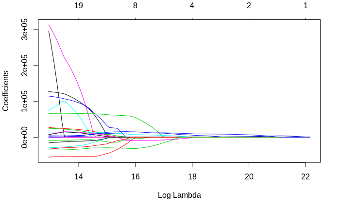

```r
plot(lasso.mod, 'lambda')
```

**Grafico de coeficientes en funcion de la norma de penalizacion**

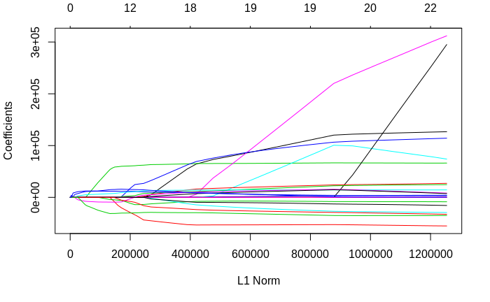

```r
plot(lasso.mod)
```

¿Qué muestra cada uno de estos graficos?

Podemos realizar los graficos para los valores de lambda en ggplot.

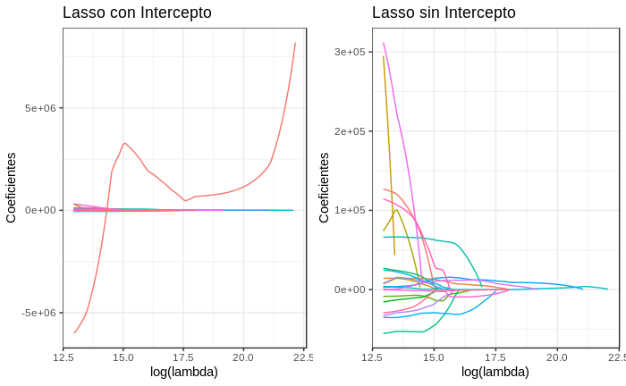

```r
g1=lasso_coef  %>% ggplot(., aes(log(lambda), estimate, group=term, color=term)) + geom_line() + theme_bw()  + theme(legend.position = 'none') +
  labs(title="Lasso con Intercepto",  y="Coeficientes")
g2=lasso_coef %>% filter(term!='(Intercept)') %>%
  ggplot(., aes(log(lambda), estimate, group=term, color=term)) + geom_line() + theme_bw()  + theme(legend.position = 'none') +
  labs(title="Lasso sin Intercepto", y="Coeficientes")
plot_grid(g1,g2)
```

Veamos un poco mejor aquellas variables que sobreviven para mayores valores de lambda ¿Qué tienen en común todas estas variables?

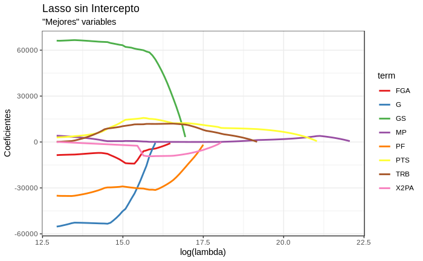

```r
lasso_coef %>% filter(term %in% c("G", "GS", "MP", "FGA", "X2PA", "TRB", "PF", "PTS")) %>%
  ggplot(., aes(log(lambda), estimate, group=term, color=term)) + geom_line(size=1) + theme_bw() +
  labs(title="Lasso sin Intercepto", y="Coeficientes", subtitle= "\"Mejores\" variables") +
  scale_color_brewer(palette = 'Set1')
```

Vemos que las variables que “sobreviven” para mayores valores de lambda son las que están medidas con una escala mayor.

### Estandarizacion en `glmnet`

Existen dos maneras de poder estandarizar las variables en `glmnet`.

1. Setear `standardize = TRUE`. Con esto se estandariza las regresoras, los coeficientes estimados estan en la escala original de la variable
2. Pasar los conjuntos de datos estandarizados.

### Lasso estandarizado

```r
# Modelo lasso
lasso.mod=glmnet(x=nba_mtx, # Matriz de regresores
                 y=nba_salary, #Vector de la variable a predecir
                 alpha=1, # Indicador del tipo de regularizacion
                 standardize = TRUE) # Estandarizamos

lasso_coef = lasso.mod %>% tidy()
lasso_coef
```

| term | step | estimate | lambda | dev.ratio |
| --- | --- | --- | --- | --- |
| (Intercept) | 1 | 8.195289e+06 | 5823214.26 | 0.00000000 |
| (Intercept) | 2 | 7.669462e+06 | 5305895.96 | 0.09126301 |
| WS | 2 | 1.614096e+05 | 5305895.96 | 0.09126301 |
| (Intercept) | 3 | 7.153731e+06 | 4834534.78 | 0.16949591 |
| WS | 3 | 2.871656e+05 | 4834534.78 | 0.16949591 |
| PTS | 3 | 1.627636e+02 | 4834534.78 | 0.16949591 |
| (Intercept) | 4 | 6.617692e+06 | 4405048.04 | 0.23846020 |
| WS | 4 | 3.607118e+05 | 4405048.04 | 0.23846020 |
| PTS | 4 | 6.177279e+02 | 4405048.04 | 0.23846020 |
| (Intercept) | 5 | 6.129248e+06 | 4013715.71 | 0.29569019 |

[output cut: 990 more lines]

#### Gráficos de analisis

El comando `plot` nos permite realizar dos graficos relevantes.

**Grafico de coeficientes en funcion del lambda**

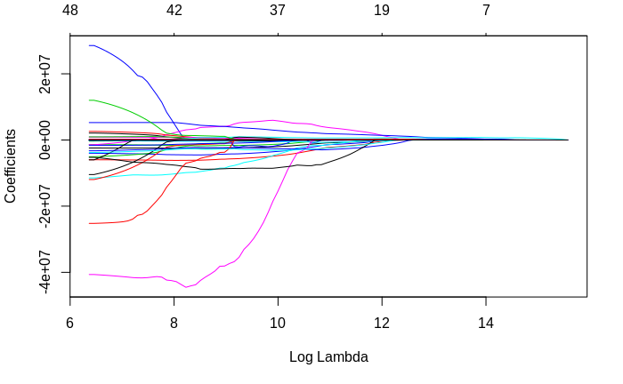

```r
plot(lasso.mod, 'lambda')
```

**Grafico de coeficientes en funcion de la norma de penalizacion**

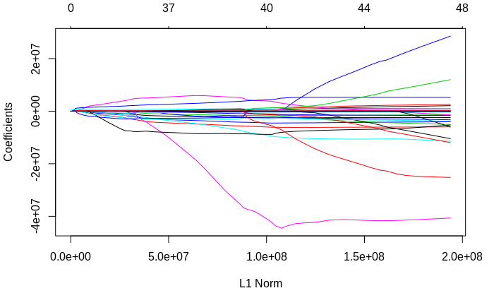

```r
plot(lasso.mod)
```

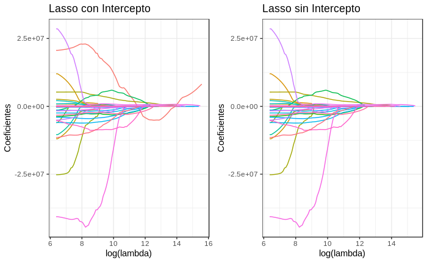

```r
g1=lasso_coef  %>% ggplot(., aes(log(lambda), estimate, group=term, color=term)) + geom_line() + theme_bw()  + theme(legend.position = 'none') +
  labs(title="Lasso con Intercepto",  y="Coeficientes")
g2=lasso_coef %>% filter(term!='(Intercept)') %>%
  ggplot(., aes(log(lambda), estimate, group=term, color=term)) + geom_line() + theme_bw()  + theme(legend.position = 'none') +
  labs(title="Lasso sin Intercepto", y="Coeficientes")
plot_grid(g1,g2)
```

¿Podemos decidir cuál es el valor óptimo de lambda?

#### Elección lambda óptimo

Para elegir el valor óptimo de lambda, lo común es realizar cross-validation. La función `cv.glmnet` nos permite realizar esto de manera sencilla.

Al igual que para la función `glmnet` cuenta con los parametros:

- **x**: matriz de variables
- **y**: vector de la variable a predecir
- **alpha**: tipo de modelo
- **standardize**: flag logico para estandarizar las variables

Nuevo parametro

- **type.measure**: funcion de perdida/error que se va a utilizar en CV. Para los modelos de regularizacion el default es MSE

**Salida Base**

```r
lasso_cv=cv.glmnet(x=nba_mtx,y=nba_salary,alpha=1, standardize = T)
lasso_cv
```

```
$lambda
 [1] 5823214.261 5305895.956 4834534.784 4405048.038 4013715.712 3657148.270 3332257.298 3036228.744 2766498.551 2520730.445 2296795.699 2092754.700
[13] 1906840.140 1737441.718 1583092.184 1442454.638 1314310.944 1197551.182 1091164.036  994228.030  905903.552  825425.578  752097.044  685282.816
[25]  624404.179  568933.833  518391.319  472338.863  430377.581  392144.022  357307.028  325564.857  296642.572  270289.664  246277.875  224399.227
[37]  204464.218  186300.181  169749.786  154669.683  140929.255  128409.488  117001.943  106607.813   97137.069   88507.679   80644.901   73480.630
[49]   66952.814   61004.910   55585.402   50647.348   46147.977   42048.318   38312.862   34909.253   31808.011   28982.275   26407.569   24061.594
[61]   21924.028   19976.358   18201.713   16584.723   15111.382   13768.929   12545.735   11431.206   10415.690    9490.388    8647.288    7879.087
[73]    7179.131    6541.357    5960.240    5430.749    4948.296    4508.703    4108.163    3743.205

$cvm
 [1] 6.363118e+13 5.926281e+13 5.433217e+13 5.000961e+13 4.628932e+13 4.319022e+13 4.048677e+13 3.815649e+13 3.616044e+13 3.447761e+13 3.311936e+13
[12] 3.202560e+13 3.113311e+13 3.039201e+13 2.980580e+13 2.925888e+13 2.857799e+13 2.795221e+13 2.745739e+13 2.703128e+13 2.669242e+13 2.646202e+13
[23] 2.627007e+13 2.611997e+13 2.600910e+13 2.591685e+13 2.585481e+13 2.585990e+13 2.593769e+13 2.603345e+13 2.610286e+13 2.616221e+13 2.623036e+13
[34] 2.630096e+13 2.635939e+13 2.649800e+13 2.666127e+13 2.682751e+13 2.702130e+13 2.718456e+13 2.729957e+13 2.740067e+13 2.748624e+13 2.753810e+13
[45] 2.755868e+13 2.759864e+13 2.765643e+13 2.774204e+13 2.787288e+13 2.798757e+13 2.815954e+13 2.838111e+13 2.857094e+13 2.879562e+13 2.903841e+13
```

[output cut: 160 more lines]

Brinda muchisima informacion:

- lambda
- cvm (Cross-validation mean): es la media del MSE (error)
- cvsd (Cross-validation Standard Error): desvio estandar del MSE (error)
- cvup y cvlo: Limite superior e inferior
- nzero: Coeficientes distintos de cero
- lambda.min: lambda para el cual el MSE (error) es minimo

En glm.fit tenemos la cantidad de variables, el valor de lambda y el porcentaje de deviance explicada por el modelo

**Grafico Base**

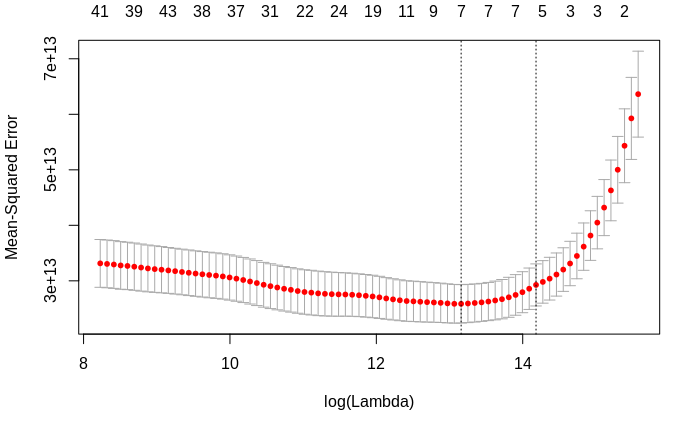

```r
plot(lasso_cv)
```

El gráfico nos muestra la media del MSE con su limite superior e inferior y la cantidad de varaibles que sobreviven para cada valor de lambda.

**Modelr**

```r
lasso_cv %>% tidy()
```

| lambda | estimate | std.error | conf.low | conf.high | nzero |
| --- | --- | --- | --- | --- | --- |
| 5823214.261 | 6.363118e+13 | 7.736798e+12 | 5.589438e+13 | 7.136798e+13 | 0 |
| 5305895.956 | 5.926281e+13 | 7.388669e+12 | 5.187414e+13 | 6.665148e+13 | 1 |
| 4834534.784 | 5.433217e+13 | 6.649727e+12 | 4.768244e+13 | 6.098189e+13 | 2 |
| 4405048.038 | 5.000961e+13 | 6.006497e+12 | 4.400312e+13 | 5.601611e+13 | 2 |
| 4013715.712 | 4.628932e+13 | 5.473897e+12 | 4.081543e+13 | 5.176322e+13 | 2 |
| 3657148.270 | 4.319022e+13 | 5.048968e+12 | 3.814125e+13 | 4.823919e+13 | 3 |
| 3332257.298 | 4.048677e+13 | 4.723632e+12 | 3.576313e+13 | 4.521040e+13 | 3 |
| 3036228.744 | 3.815649e+13 | 4.465990e+12 | 3.369050e+13 | 4.262248e+13 | 3 |
| 2766498.551 | 3.616044e+13 | 4.262311e+12 | 3.189813e+13 | 4.042275e+13 | 3 |
| 2520730.445 | 3.447761e+13 | 4.107387e+12 | 3.037022e+13 | 3.858499e+13 | 3 |

[output cut: 70 more lines]

```r
lasso_cv %>% glance()
```

| lambda.min | lambda.1se |
| --- | --- |
| 518391.3 | 1442455 |

Seleccionamos el lambda optimo para crear el modelo final

```r
lasso_lambda_opt = lasso_cv$lambda.min
lasso_opt = glmnet(x=nba_mtx, # Matriz de regresores
                 y=nba_salary, #Vector de la variable a predecir
                 alpha=1, # Indicador del tipo de regularizacion
                 standardize = TRUE,  # Estandarizamos
                 lambda = lasso_lambda_opt)
# Salida estandar
lasso_opt
```

```
Call:  glmnet(x = nba_mtx, y = nba_salary, alpha = 1, lambda = lasso_lambda_opt,      standardize = TRUE)

     Df   %Dev Lambda
[1,]  7 0.6376 518400
```

```r
# Tidy
lasso_opt %>% tidy()
```

| term | step | estimate | lambda | dev.ratio |
| --- | --- | --- | --- | --- |
| (Intercept) | 1 | -3997069.98 | 518391.3 | 0.6376339 |
| Age | 1 | 68604.72 | 518391.3 | 0.6376339 |
| GS | 1 | 58374.29 | 518391.3 | 0.6376339 |
| USG. | 1 | 225123.33 | 518391.3 | 0.6376339 |
| DWS | 1 | 644656.96 | 518391.3 | 0.6376339 |
| WS | 1 | 677186.90 | 518391.3 | 0.6376339 |
| VORP | 1 | 209796.19 | 518391.3 | 0.6376339 |
| X3P | 1 | 12983.26 | 518391.3 | 0.6376339 |

```r
# Glance
lasso_opt %>% glance()
```

| nulldev | npasses |
| --- | --- |
| 1.103981e+16 | 115 |

### Ridge

En este caso vamos a trabajar con $\alpha=0$. Vamos a replicar lo que ya realizamos para Lasso.

1. ¿Cuál es la penalización que introduce el modelo Ridge?
2. ¿Cómo impacta esto en las variables?

```r
ridge.mod=glmnet(x=nba_mtx, # Matriz de regresores
                 y=nba_salary, #Vector de la variable a predecir
                 alpha=0, # Indicador del tipo de regularizacion
                 standardize = TRUE)

ridge_coef= ridge.mod %>% tidy()
ridge_coef
```

| term | step | estimate | lambda | dev.ratio |
| --- | --- | --- | --- | --- |
| (Intercept) | 1 | 8.195289e+06 | 5823214261 | 2.226076e-35 |
| PosPF | 1 | -1.109435e-30 | 5823214261 | 2.226076e-35 |
| PosPG | 1 | -9.763565e-31 | 5823214261 | 2.226076e-35 |
| PosSF | 1 | 4.645692e-31 | 5823214261 | 2.226076e-35 |
| PosSG | 1 | -1.222454e-30 | 5823214261 | 2.226076e-35 |
| Age | 1 | 2.665862e-31 | 5823214261 | 2.226076e-35 |
| G | 1 | 1.421392e-31 | 5823214261 | 2.226076e-35 |
| GS | 1 | 1.777966e-31 | 5823214261 | 2.226076e-35 |
| MP | 1 | 6.264014e-33 | 5823214261 | 2.226076e-35 |
| PER | 1 | 9.378149e-31 | 5823214261 | 2.226076e-35 |

[output cut: 990 more lines]

¿Qué ven de distinto en los coeficientes estimados del modelo respecto a Lasso?

#### Gráficos de analisis

**Grafico de coeficientes en funcion del lambda**

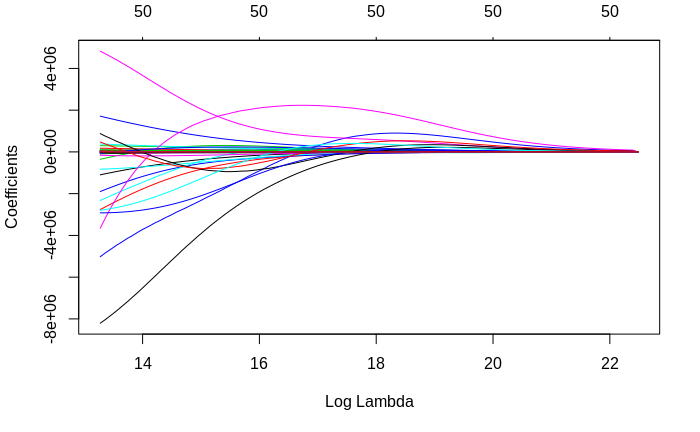

```r
plot(ridge.mod, 'lambda')
```

¿Qué ven de distinto en este gráfico respecto al que obtuvimos con la regresión Lasso?

**Grafico de coeficientes en funcion de la norma de penalizacion**

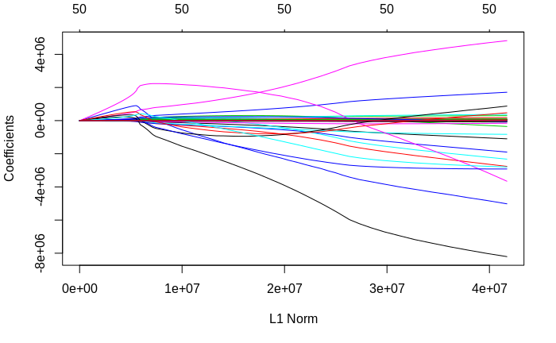

```r
plot(ridge.mod)
```

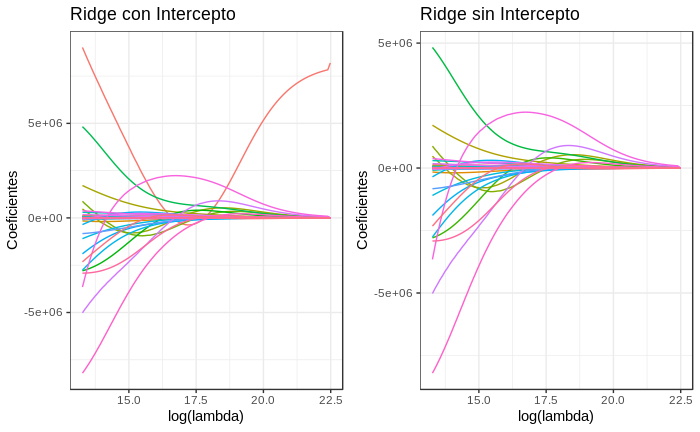

```r
g1=ridge_coef  %>% ggplot(., aes(log(lambda), estimate, group=term, color=term)) + geom_line() + theme_bw()  + theme(legend.position = 'none') +
  labs(title="Ridge con Intercepto",  y="Coeficientes")
g2=ridge_coef %>% filter(term!='(Intercept)') %>%
  ggplot(., aes(log(lambda), estimate, group=term, color=term)) + geom_line() + theme_bw()  + theme(legend.position = 'none') +
  labs(title="Ridge sin Intercepto", y="Coeficientes")
plot_grid(g1,g2)
```

#### Elección lambda óptimo

```r
ridge_cv=cv.glmnet(x=nba_mtx,y=nba_salary,alpha=0, standardize = T)
```

**Grafico Base**

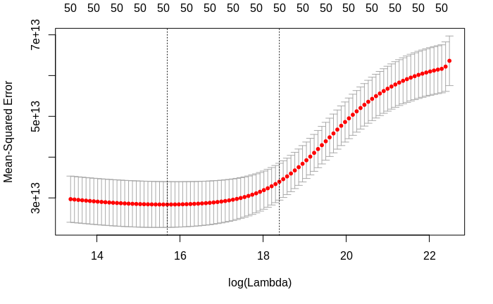

```r
plot(ridge_cv)
```

Seleccionamos el lambda óptimo para crear el modelo final

```r
ridge_lambda_opt = ridge_cv$lambda.min
ridge_opt = glmnet(x=nba_mtx, # Matriz de regresores
                 y=nba_salary, #Vector de la variable a predecir
                 alpha=0, # Indicador del tipo de regularizacion
                 standardize = TRUE,  # Estandarizamos
                 lambda = ridge_lambda_opt)
# Salida estandar
ridge_opt
```

```
Call:  glmnet(x = nba_mtx, y = nba_salary, alpha = 0, lambda = ridge_lambda_opt,      standardize = TRUE)

     Df   %Dev  Lambda
[1,] 50 0.6392 6541000
```

```r
# Tidy
ridge_opt %>% tidy()
```

| term | step | estimate | lambda | dev.ratio |
| --- | --- | --- | --- | --- |
| (Intercept) | 1 | 1856077.2752 | 6541357 | 0.639227 |
| PosPF | 1 | -208529.1242 | 6541357 | 0.639227 |
| PosPG | 1 | -457911.0613 | 6541357 | 0.639227 |
| PosSF | 1 | 302385.8176 | 6541357 | 0.639227 |
| PosSG | 1 | -347666.1800 | 6541357 | 0.639227 |
| Age | 1 | 94776.9476 | 6541357 | 0.639227 |
| G | 1 | -19323.9001 | 6541357 | 0.639227 |
| GS | 1 | 26294.5236 | 6541357 | 0.639227 |
| MP | 1 | 349.9854 | 6541357 | 0.639227 |
| PER | 1 | 44429.6681 | 6541357 | 0.639227 |

[output cut: 41 more lines]

### Elastic Net

El modelo Elastic Net incorpora los dos tipos de penalización: Lasso (Norma L1) y Ridge (Norma L2). El parámetro $\alpha$ regula la importancia de cada penalización, cuanto más cerca de cero será más importante la penalización del tipo Ridge y más cerca de 1, la tipo Lasso.

En este caso vamos a trabajar con $\alpha=0.5$. Vamos a replicar lo que ya realizamos para Lasso y Ridge

```r
elastic.mod=glmnet(x=nba_mtx, # Matriz de regresores
                 y=nba_salary, #Vector de la variable a predecir
                 alpha=0.5, # Indicador del tipo de regularizacion
                 standardize = TRUE)

elastic_coef= elastic.mod %>% tidy()
elastic_coef
```

| term | step | estimate | lambda | dev.ratio |
| --- | --- | --- | --- | --- |
| (Intercept) | 1 | 8.195289e+06 | 11646428.52 | 0.00000000 |
| (Intercept) | 2 | 7.810419e+06 | 10611791.91 | 0.06353197 |
| WS | 2 | 8.263363e+04 | 10611791.91 | 0.06353197 |
| PTS | 2 | 1.775254e+02 | 10611791.91 | 0.06353197 |
| (Intercept) | 3 | 7.319554e+06 | 9669069.57 | 0.13296409 |
| WS | 3 | 1.383158e+05 | 9669069.57 | 0.13296409 |
| FG | 3 | 5.260318e+02 | 9669069.57 | 0.13296409 |
| PTS | 3 | 4.575436e+02 | 9669069.57 | 0.13296409 |
| (Intercept) | 4 | 6.827507e+06 | 8810096.08 | 0.19735589 |
| GS | 4 | 1.932645e+03 | 8810096.08 | 0.19735589 |

[output cut: 990 more lines]

¿Qué ven de distinto en los coeficientes estimados del modelo respecto a Lasso y Ridge?

#### Gráficos de analisis

**Grafico de coeficientes en funcion del lambda**

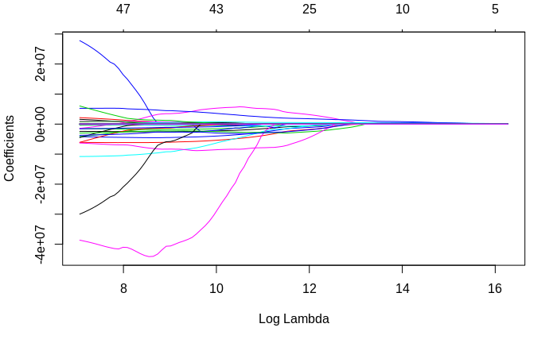

```r
plot(elastic.mod, 'lambda')
```

¿Qué ven en este gráfico de distinto a los dos anteriores?

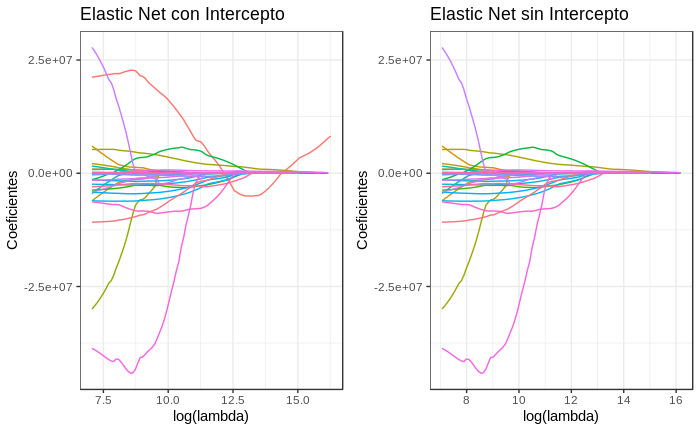

```r
g1=elastic_coef  %>% ggplot(., aes(log(lambda), estimate, group=term, color=term)) + geom_line() + theme_bw()  + theme(legend.position = 'none') +
  labs(title="Elastic Net con Intercepto",  y="Coeficientes")
g2=elastic_coef %>% filter(term!='(Intercept)') %>%
  ggplot(., aes(log(lambda), estimate, group=term, color=term)) + geom_line() + theme_bw()  + theme(legend.position = 'none') +
  labs(title="Elastic Net sin Intercepto", y="Coeficientes")
plot_grid(g1,g2)
```

#### Elección lambda óptimo

```r
elastic_cv=cv.glmnet(x=nba_mtx,y=nba_salary,alpha=0.5, standardize = T)
```

**Grafico Base**

Presten especial atención al eje superior ¿Qué está sucediendo?

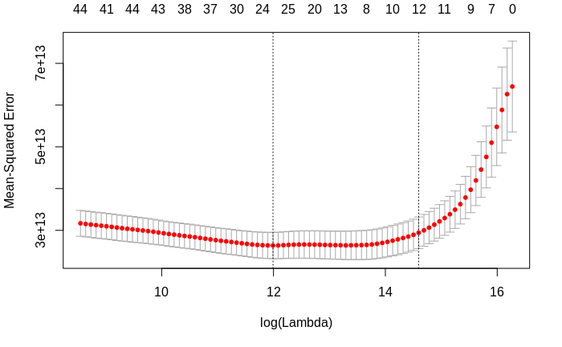

```r
plot(elastic_cv)
```

Seleccionamos el lambda optimo para crear el modelo final

```r
elastic_lambda_opt = elastic_cv$lambda.min
elastic_opt = glmnet(x=nba_mtx, # Matriz de regresores
                 y=nba_salary, #Vector de la variable a predecir
                 alpha=0.5, # Indicador del tipo de regularizacion
                 standardize = TRUE,  # Estandarizamos
                 lambda = elastic_lambda_opt)
# Salida estandar
elastic_opt
```

```
Call:  glmnet(x = nba_mtx, y = nba_salary, alpha = 0.5, lambda = elastic_lambda_opt,      standardize = TRUE)

     Df   %Dev Lambda
[1,] 25 0.6949 161300
```

```r
# Tidy
elastic_opt %>% tidy()
```

| term | step | estimate | lambda | dev.ratio |
| --- | --- | --- | --- | --- |
| (Intercept) | 1 | 1445762.1422 | 161289.8 | 0.694862 |
| PosPF | 1 | -649972.8670 | 161289.8 | 0.694862 |
| PosPG | 1 | -1801249.8837 | 161289.8 | 0.694862 |
| PosSG | 1 | -1116850.3980 | 161289.8 | 0.694862 |
| Age | 1 | 129071.2885 | 161289.8 | 0.694862 |
| G | 1 | -49653.7315 | 161289.8 | 0.694862 |
| GS | 1 | 60136.8378 | 161289.8 | 0.694862 |
| MP | 1 | 1106.9836 | 161289.8 | 0.694862 |
| X3PAr | 1 | -597891.3000 | 161289.8 | 0.694862 |
| FTr | 1 | 3166275.2977 | 161289.8 | 0.694862 |

[output cut: 16 more lines]

### Breve comparacion entre modelos

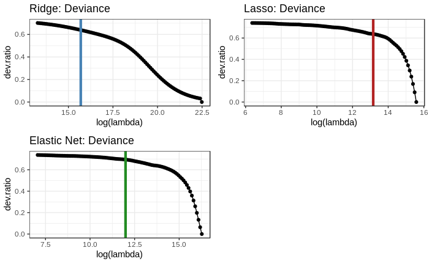

```r
ridge_dev = ridge_coef %>% select(lambda, dev.ratio) %>% distinct() %>%
  ggplot(., aes(log(lambda), dev.ratio)) +
  geom_point() +
  geom_line() +
  geom_vline(xintercept = log(ridge_lambda_opt), color='steelblue', size=1.5) +
  labs(title='Ridge: Deviance') +
  theme_bw()
lasso_dev = lasso_coef %>% select(lambda, dev.ratio) %>% distinct() %>%
  ggplot(., aes(log(lambda), dev.ratio)) +
  geom_point() +
  geom_line() +
  geom_vline(xintercept = log(lasso_lambda_opt), color='firebrick', size=1.5) +
  labs(title='Lasso: Deviance') +
  theme_bw()
elastic_dev = elastic_coef %>% select(lambda, dev.ratio) %>% distinct() %>%
  ggplot(., aes(log(lambda), dev.ratio)) +
  geom_point() +
  geom_line() +
  geom_vline(xintercept = log(elastic_lambda_opt), color='forestgreen', size=1.5) +
  labs(title='Elastic Net: Deviance') +
  theme_bw()
plot_grid(ridge_dev, lasso_dev, elastic_dev)
```

## Testing

Con los modelos optimos que encontramos pueden probar cual es el MSE y RMSE en los datasets de training y testing, para decidir cual es el modelo que minimiza el error en las predicciones.